# Chuyên đề Data Visualization in R

Duc Nguyen | Chuyên đào tạo kỹ năng R | `www.tuhocr.com`

Jan 29, 2023

**Các bạn đăng ký học viên để truy cập file này có kèm hyperlink liên kết trực tiếp với tài liệu gốc giúp thuận tiện tra cứu thông tin.**

**Liên hệ: `tuhocr.com@gmail.com`**

### Cơ sở lý thuyết về trực quan hóa dữ liệu trong R

- [Nguyên tắc vẽ đồ thị](https://tanduc307.github.io/light/dvsr/Jones%20et%20al.%20-%202023%20-%20The%20R%20Book.pdf#page=279) (Jones et al., 2023, p. 249)
- [Lý do lattice graphic ra đời](https://tanduc307.github.io/light/dvsr/Sarkar%20-%202008%20-%20Lattice%20Multivariate%20Data%20Visualization%20with%20R.pdf#page=18) (Sarkar, 2008, p. 1)
- [So sánh giữa `base` và `grid` graphic](https://tanduc307.github.io/light/dvsr/Murrell%20-%202019%20-%20R%20Graphics.pdf#page=40) (Murrell, 2019, p. 21)

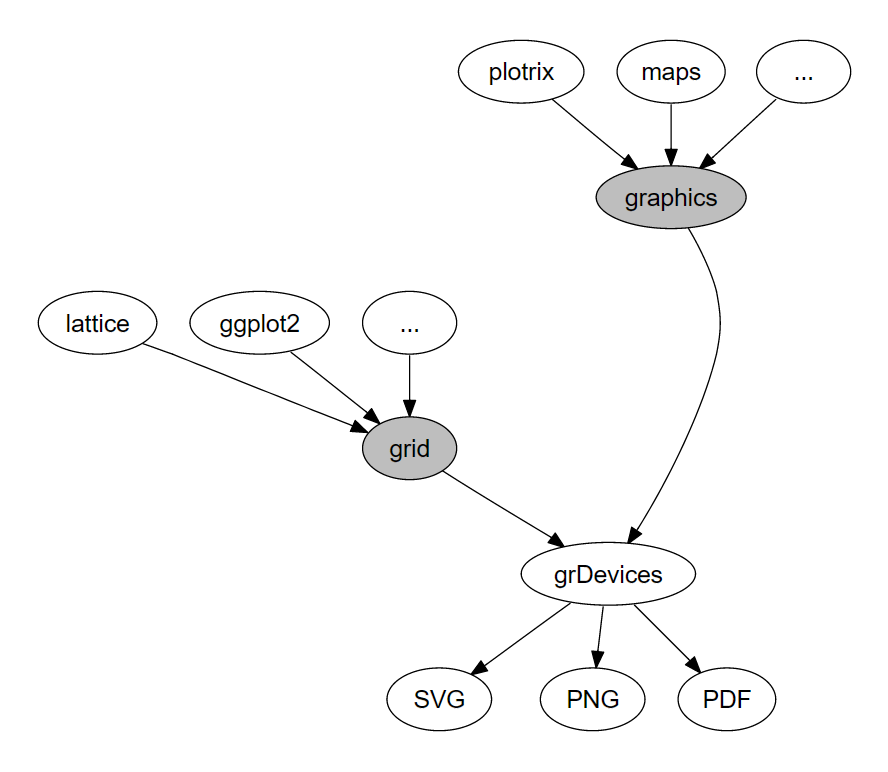

**Sơ đồ tương quan các hệ thống plotting trong R**

### Example `base-R` graphic

Đặc điểm của các lệnh trong `base-R` là lệnh `plot()` sẽ tạo đồ thị, sau đó các lệnh phụ như `abline()` hay `text()` sẽ chèn thêm thông tin cần thiết, theo thứ tự từ trên xuống.

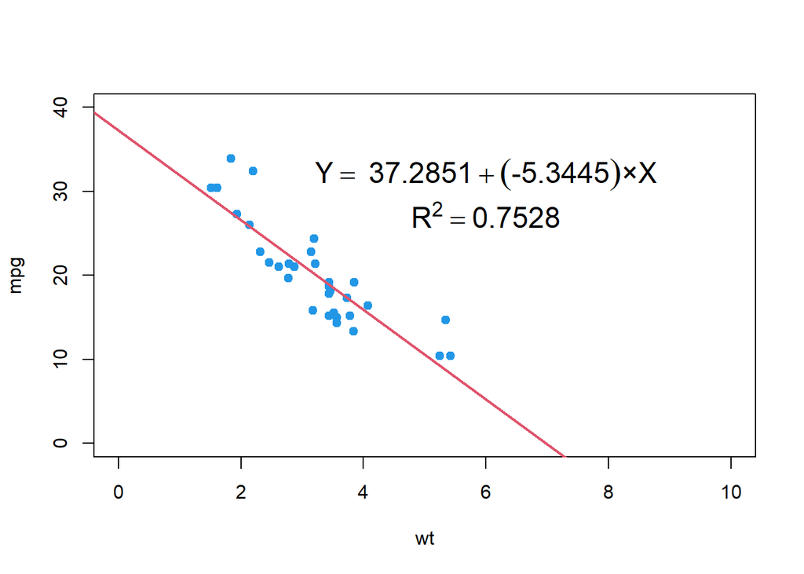

```r
fit_lm <- lm(mpg ~ wt, data = mtcars)
plot(mpg ~ wt, data = mtcars, pch = 19, col = 4,
     ylim = c(0, 40), xlim = c(0, 10))
abline(fit_lm, col = 2, lwd = 2)
text(x = 6, y = max(mtcars$mpg)-4,
     bquote(atop(Y == ~ .(round(fit_lm$coefficients[1], 4)) +
                     (.(round(fit_lm$coefficients[2], 4))) * "\u00D7" * X,
                 R^2 == .(round(unclass(summary(fit_lm))$r.squared, 4)))),
     cex = 1.5)
```

### Example `lattice` package

Đặc điểm của các lệnh trong `lattice` là toàn bộ format sẽ nằm trong lệnh *plot* tương ứng, không tách ra từng lệnh phụ riêng lẻ như `base-R graphic`.

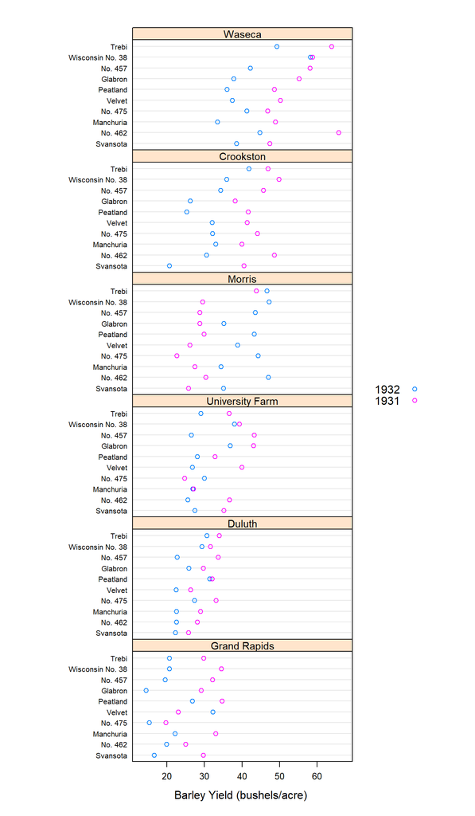

```r
library("lattice")
dotplot(variety ~ yield | site, data = barley, groups = year,
        key = simpleKey(levels(barley$year), space = "right"),
        xlab = "Barley Yield (bushels/acre) ",
        aspect = 0.5, layout = c(1, 6), ylab=NULL,
        scales = list(tck = c(1, 0), x = list(cex = 0.8), y = list(cex = 0.65)),
        par.strip.text = list(cex=0.9)
        )
```

### Example `ggplot2` package

Đặc điểm các lệnh trong `ggplot2` là đưa thông tin vào đồ thị theo kiểu layer/lớp, mỗi lớp được đưa vào sử dụng dấu `+`, nếu cần xuống hàng thì xuống hàng ngay sau dấu `+` để R biết được là các lệnh này thuộc cùng 1 câu lệnh chung.

```r
options(width = 200)
## Edgar Anderson's Iris Data
## Description
# This famous (Fisher's or Anderson's) iris data set gives
# the measurements in centimeters of the variables sepal length and width and petal length and width,
# respectively, for 50 flowers from each of 3 species of iris.
# The species are Iris setosa, versicolor, and virginica.

head(iris)
```

```
##   Sepal.Length Sepal.Width Petal.Length Petal.Width Species
## 1          5.1         3.5          1.4         0.2  setosa
## 2          4.9         3.0          1.4         0.2  setosa
## 3          4.7         3.2          1.3         0.2  setosa
## 4          4.6         3.1          1.5         0.2  setosa
## 5          5.0         3.6          1.4         0.2  setosa
## 6          5.4         3.9          1.7         0.4  setosa
```

```r
str(iris)
```

```
## 'data.frame':    150 obs. of  5 variables:
##  $ Sepal.Length: num  5.1 4.9 4.7 4.6 5 5.4 4.6 5 4.4 4.9 ...
##  $ Sepal.Width : num  3.5 3 3.2 3.1 3.6 3.9 3.4 3.4 2.9 3.1 ...
##  $ Petal.Length: num  1.4 1.4 1.3 1.5 1.4 1.7 1.4 1.5 1.4 1.5 ...
##  $ Petal.Width : num  0.2 0.2 0.2 0.2 0.2 0.4 0.3 0.2 0.2 0.1 ...
##  $ Species     : Factor w/ 3 levels "setosa","versicolor",..: 1 1 1 1 1 1 1 1 1 1 ...
```

```r
summary(iris)
```

```
##   Sepal.Length    Sepal.Width     Petal.Length    Petal.Width          Species
##  Min.   :4.300   Min.   :2.000   Min.   :1.000   Min.   :0.100   setosa    :50
##  1st Qu.:5.100   1st Qu.:2.800   1st Qu.:1.600   1st Qu.:0.300   versicolor:50
##  Median :5.800   Median :3.000   Median :4.350   Median :1.300   virginica :50
##  Mean   :5.843   Mean   :3.057   Mean   :3.758   Mean   :1.199
##  3rd Qu.:6.400   3rd Qu.:3.300   3rd Qu.:5.100   3rd Qu.:1.800
##  Max.   :7.900   Max.   :4.400   Max.   :6.900   Max.   :2.500
```

**Vẽ đồ thị scatter plot**

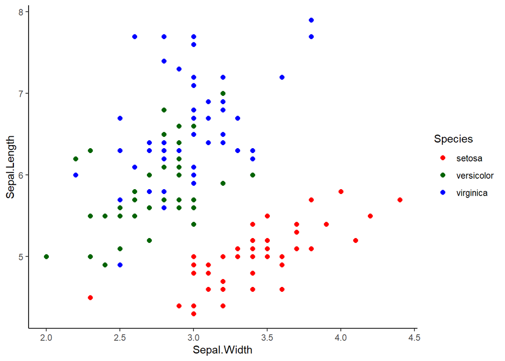

```r
library("ggplot2")
library("dplyr")

ggplot(iris, aes(x = Sepal.Width, y = Sepal.Length, color = Species)) +
    geom_point(size=2) +
    labs(col = "Species") +
    scale_color_manual(labels = c("setosa", "versicolor", "virginica"),
                       values = c("red", "darkgreen", "blue")) +
    theme_classic()
```

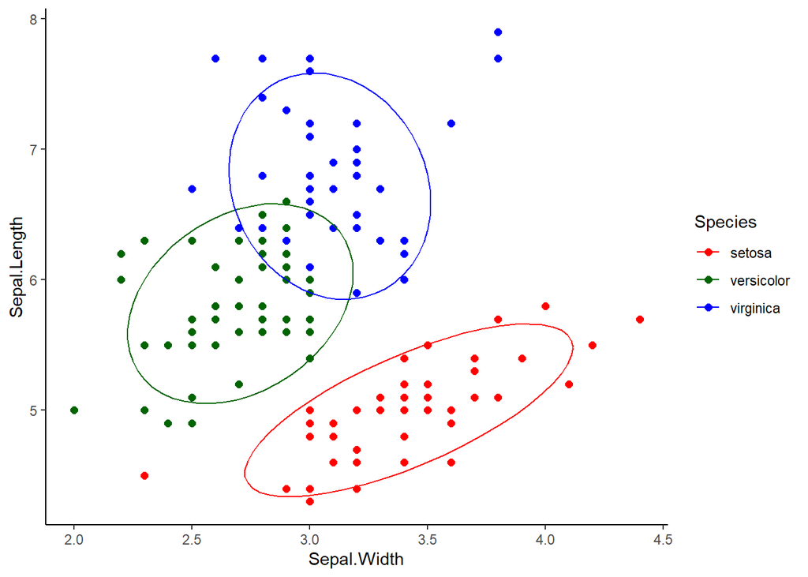

```r
iris.sc <- iris
iris.sc[,1:4] <- scale(iris[,1:4])
iris.sc.input <- iris.sc[,1:4]

set.seed(123) # Set seed number
irisKM.mod <- kmeans(iris.sc.input, centers = 3, nstart = 100)

groupPred <- factor(irisKM.mod$cluster, levels = c(1,2,3), ordered = FALSE)
iris$KMpred <- groupPred

groupPred <- factor(irisKM.mod$cluster, levels = c(1,2,3), ordered = FALSE)
iris$KMpred <- groupPred

# Plot the Data
ggplot(iris, aes(y = Sepal.Length, x = Sepal.Width, col = KMpred)) +
    geom_point(size=2) +
    stat_ellipse(level = 0.9) +
    labs(col = "Species") +
    scale_color_manual(labels = c("setosa", "versicolor", "virginica"),
                       values = c("red", "darkgreen", "blue")) +
    theme_classic()
```

### Tài liệu tham khảo

Jones, E., Harden, S., & Crawley, M. J. (2023). *The R Book* (3rd ed.). Wiley.

Murrell, P. (2019). *R Graphics* (3rd ed.). CRC Press, Taylor & Francis Group.

Sarkar, D. (2008). *Lattice: Multivariate Data Visualization with R*. Springer New York.

### Tham gia khóa học

**Để học R bài bản từ A đến Z, thân mời Bạn tham gia khóa học “HDSD R để xử lý dữ liệu”**

**ĐĂNG KÝ NGAY: `https://www.tuhocr.com/register`**

[figure not shown]